# in-class activity, ggplot

## Task 2b

Recreate the barplot in Task 2a for different car `Origin`, such that you create one barplot for each `Origin` category.

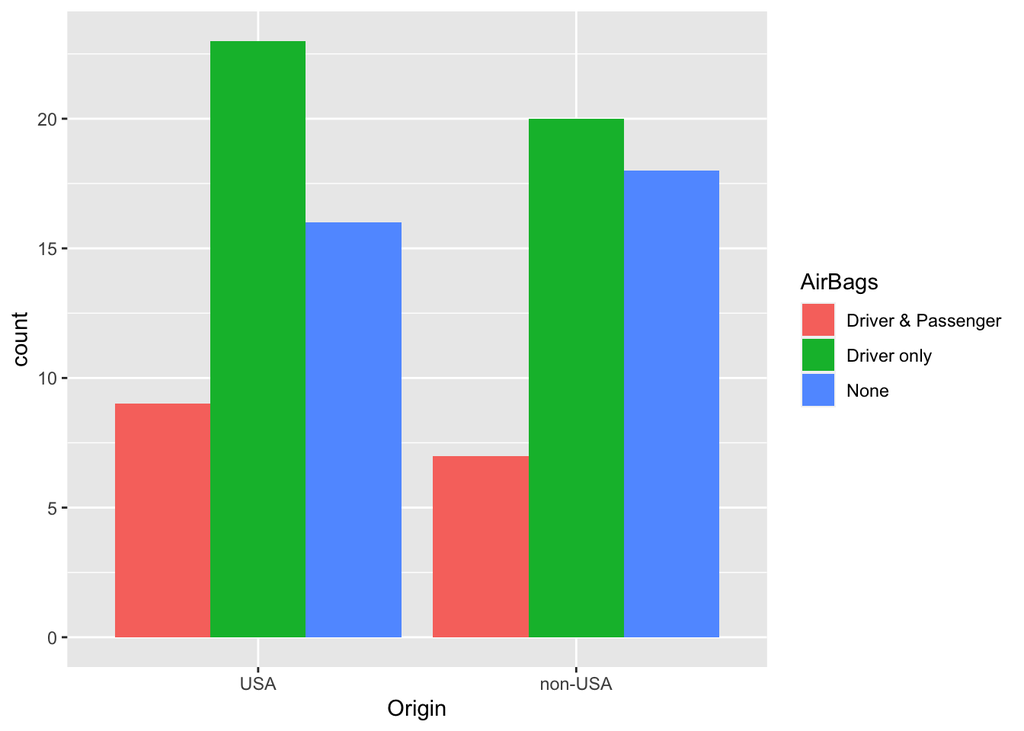

```r
ggplot(Cars93,aes(x=Origin)) +
      geom_bar(aes(fill=AirBags),position='dodge')
```

## Task 3a

Load Australia state map data via running:

```r
# install the packages below by uncommenting the lines. You need to do this only once.
#install.packages('maps')
#install.packages('ozmaps')
#install.packages('sf')
library(maps)
library(ozmaps)
library(sf)
oz_states <- ozmaps::ozmap_states

# Display the data
head(oz_states)
```

```
## Simple feature collection with 6 features and 1 field
## Geometry type: MULTIPOLYGON
## Dimension:     XY
## Bounding box:  xmin: 112.9211 ymin: -43.63203 xmax: 153.6299 ymax: -9.229287
## Geodetic CRS:  GDA94
## # A tibble: 6 × 2
##   NAME                                                                  geometry
##   <chr>                                                       <MULTIPOLYGON [°]>
## 1 New South Wales   (((150.7016 -35.12286, 150.6611 -35.11782, 150.6373 -35.146…
## 2 Victoria          (((146.6196 -38.70196, 146.6721 -38.70259, 146.6744 -38.713…
## 3 Queensland        (((148.8473 -20.3457, 148.8722 -20.37575, 148.8515 -20.3809…
## 4 South Australia   (((137.3481 -34.48242, 137.3749 -34.46885, 137.3805 -34.497…
## 5 Western Australia (((126.3868 -14.01168, 126.3625 -13.98264, 126.3765 -13.974…
## 6 Tasmania          (((147.8397 -40.29844, 147.8902 -40.30258, 147.8812 -40.325…
```

## Task 3a

Create a map of Australia using ggplot.

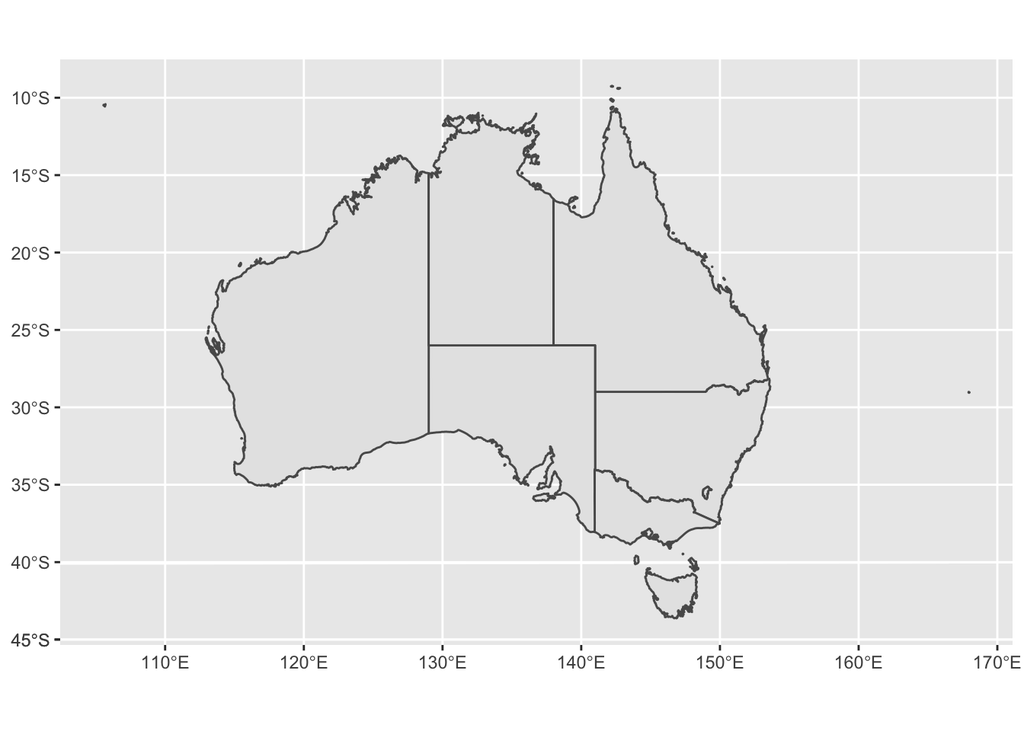

```r
ggplot(oz_states) +
  geom_sf()
```

## Task 3b

Modify your map such that each state is displayed with a different color. (Hint: use the fill option as an aes setting.)

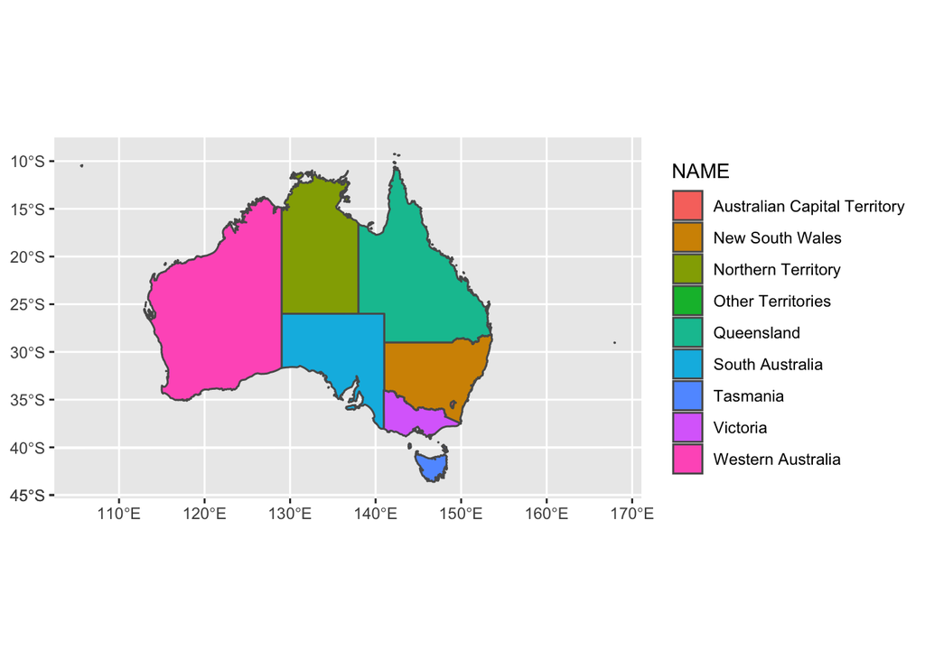

```r
ggplot(oz_states) +
  geom_sf(aes(fill = NAME))
```

## Task 3c Read in the capital city dataframe by running:

```r
oz_capitals <- tibble::tribble(
  ~city,           ~lat,     ~lon,
  "Sydney",    -33.8688, 151.2093,
  "Melbourne", -37.8136, 144.9631,
  "Brisbane",  -27.4698, 153.0251,
  "Adelaide",  -34.9285, 138.6007,
  "Perth",     -31.9505, 115.8605,
  "Hobart",    -42.8821, 147.3272,
  "Canberra",  -35.2809, 149.1300,
  "Darwin",    -12.4634, 130.8456,
)
```

Display the capitals as points on your map from Task 3a. (Hint: combine geom_sf() with geom_point())

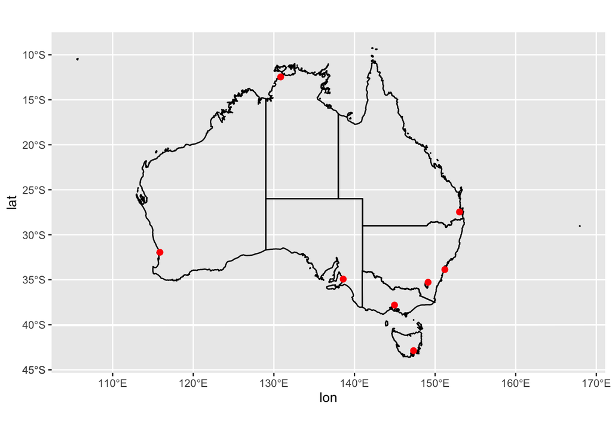

```r
ggplot() +
  geom_sf(data = oz_states, colour = "black", fill = NA) +
  geom_point(data = oz_capitals, aes(x = lon, y = lat), col = "red", size=2)
```

## Task 3d

Let’s take a look at different projection output. Change your map’s projection to epsg 3112 by adding + coord_sf(). Recall the option that goes inside is st_crs(4_digit_code)

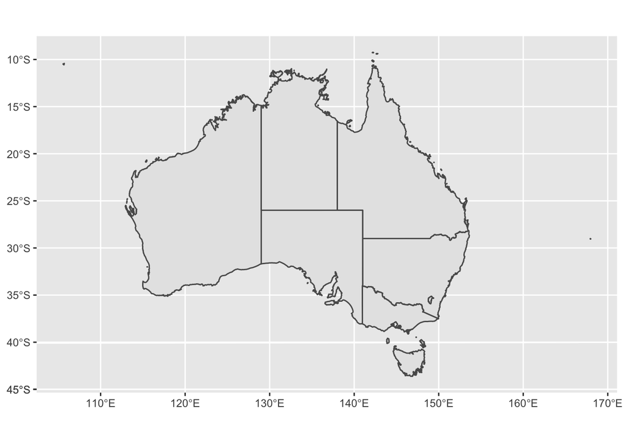

```r
ggplot(oz_states) + geom_sf()
```

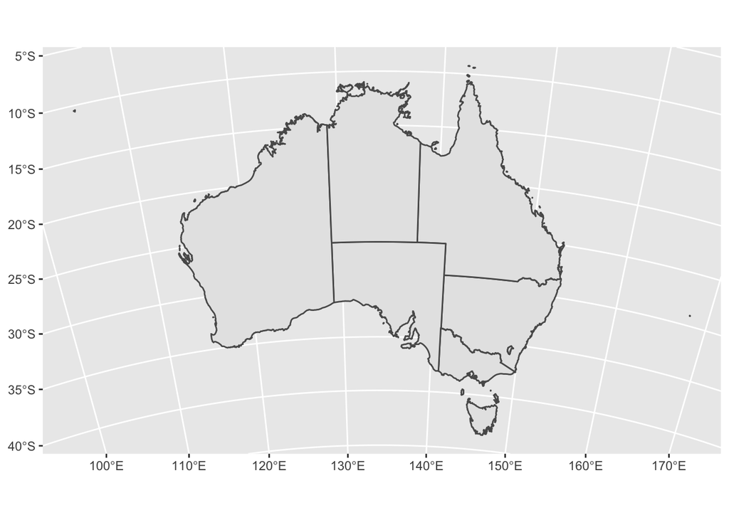

```r
ggplot(oz_states) + geom_sf() + coord_sf(crs = st_crs(3112))
```

## Task 3e

Lastly, let’s display the same map using mapview()

```r
#install.packages('mapview')
library(mapview)
mapview(oz_states)
```

[interactive chart not shown]

```r
# you can use the mapview options to turn off legends, hover etc: legend = FALSE, label = FALSE, popup = FALSE
```

## Task 3f

Let’s display the capitals on the map like before. First conver the `oz_capitals` dataframe to spatial dataframe object:

```r
capitals_geo <- st_as_sf(oz_capitals, coords = c("lon", "lat"))
```

Now add the new spatial capitals object via +

```r
mapview(oz_states) + mapview(capitals_geo,col.regions='red',legend=F)
```

[interactive chart not shown]